# Project 4

US elections data

Sciper 359523

# 1 Introduction

The period between 1948 and 1992 was a tumultuous time in American politics, marked by significant changes and transformations. During these years, the United States went through some of its most challenging periods, including the Cold War, the civil rights movement, and the Vietnam War. The presidential elections during this period reflect the social and political changes that took place in the country. In 1948, incumbent President Harry S. Truman, a Democrat, was facing a divided party and a difficult re-election campaign. He managed to win the election but his second term was marked by the Korean War and efforts to contain communism around the world. The Korean War was then ended under the presidency of Eisenhower(1952). His successor, John F.Kennedy (1960) faced the Civil Rights Movement, the Bay of Pigs invasion, and the Cuban Missile Crisis, which brought the world to the brink of nuclear war. After Kennedy’s death, Johnson who had replaced him was elected (1964) and his presidency was marked by the Vietnam War. In 1976, Democrat Jimmy Carter’s presidency was marked by significant foreign policy challenges, including the Iranian Hostage Crisis and the Soviet invasion of Afghanistan. Republican Reagan’s presidency (1980) was marked by the Reagan revolution and efforts towards ending the cold war, that was finally ended under Republican Bush’s presidency (1988), also marked by the Gulf War. [1], [2]

In this project, we explore the presidential elections of this era, focusing on the outcomes that shaped the political landscape of the United States. We want specifically to assess whether the elections outcome can be predicted by linear models.

# 2 Data characteristics

The data set consists of election results such as the outcome variable which corresponds to the party candidate’s share of the vote in the given state and year; but also nationwide variables such as poll results or economic growth (GDP). It also contains statewide variable concerning previous elections’ results and indicators of state ideology and position towards the candidate. Finally, it contains regional variables accounting for southern states or New England indicator. We include in this data set a variable that corresponds to the region divided in Northeast, South, Midwest and West, as well as a variable corresponding to the incumbent president’s party (Democrat or Republican).

# 3 Linear model

## 3.1 Model building

The initial model we developed included all variables from the dataset, but the results showed that some variables had NA coefficients due to the presence of collinearity relations in the design matrix. To improve the model, we conducted variable selection based on plausibility. After careful consideration, we found that variables n1, n2, n3, n4, and s9 were not useful in our analysis due to their correlation with the year variable, and the fact that they provided unique values for each state and region when the year was fixed. Additionally, we removed the variable that corresponded to the number of electors in a given state and year since our outcome variable was the Democratic party’s share of the vote. We also discarded the ‘measure of state ideology’ and ‘ideological compatibility with candidates’ due to their complexity to interpret.

For our initial regression, we did not include the ‘region’ variable but did include the ‘state’ variable.

## 3.2 Diagnostics

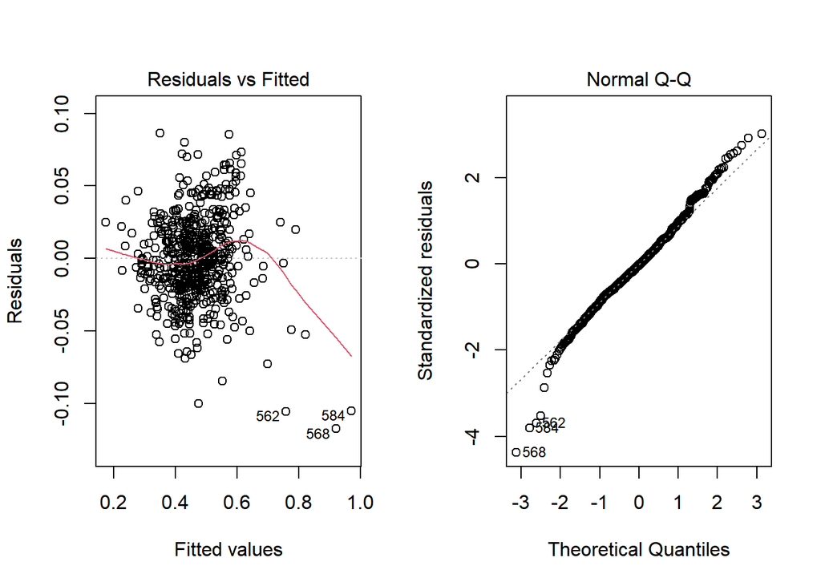

Figure 2: Residuals diagnostics for the linear model

However, when looking at the residuals grouped by region within year in *Figure 3*, it appears clearly that there is grouping between regions within year. This is due to the fact that the linear model is not appropriate for this type of data. Indeed, there is clustering (or nesting) in the data, ie, there is a hierarchical structure in the data where individual observations are nested within higher-level units. There is a year effect as well as a region effect for each year. The linear model that was used here does not account for the clustering in the data, which leads to biased estimates and incorrect model. We build in the next section a mixed model that allows observations from the same year to be correlated and observations within the same year and the same region to be correlated even further.

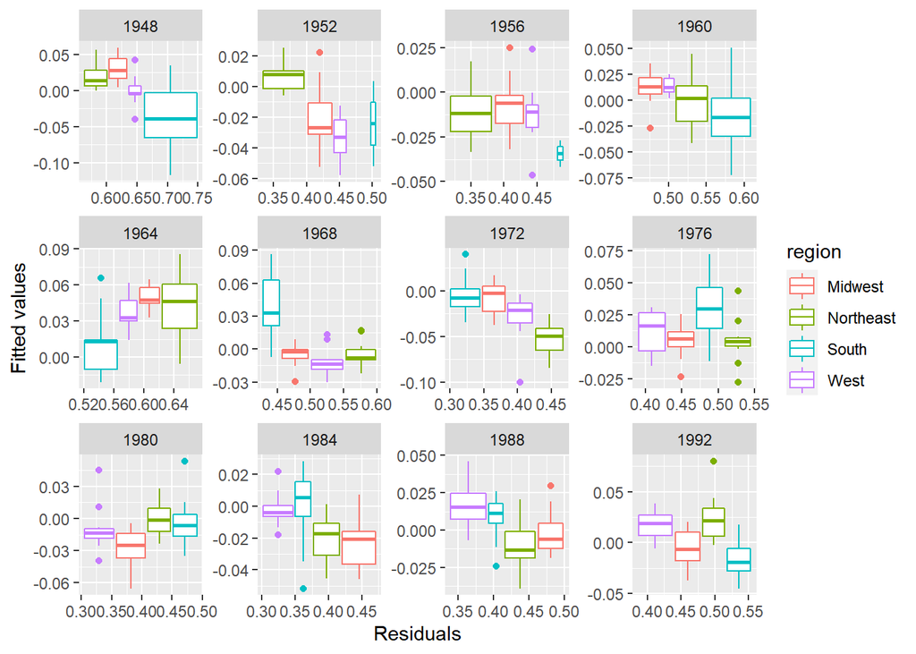

# 4 Mixed model

We build in this section a mixed model to be able to account for the within-group correlation structure of the data by including random effects for each level of nesting.

We choose to include in the model ‘fixed’ effects as follows :

We include the variable corresponding to the democratic majority in the state legislature as a variable for which the intercept can vary across year and region but also the slope. Indeed, with some descriptive statistics, one can see that the evolution is very different for every state, and that they also start with very different intercepts.

In a first model, we consider two levels of grouping: observations for the same year can be correlated, and observation within the same year and the same region can be correlated even further. But, when observing the results, it appears that the proportion of variance explained by the year grouping is neglectable compared to the one of region within year. Thus, we discard it and fit the model with only region within year as a grouping factor.

# 5 Interpretation

*Table 1 : anova of the fixed effects*

| Variable | Sum Sq | Mean Sq | NumDF | DenDF | F value | Pr(>F) |
| --- | --- | --- | --- | --- | --- | --- |
| s1 | 0.177346 | 0.177346 | 1 | 507.66 | 169.009 | < 2.2e-16 |
| s2 | 0.082547 | 0.082547 | 1 | 513.63 | 78.6668 | < 2.2e-16 |
| s3 | 0.047104 | 0.023552 | 2 | 490.62 | 22.4449 | 4.707e-10 |
| s4 | 0.012284 | 0.006142 | 2 | 503.49 | 5.8534 | 0.003069 |
| n1 | 0.147673 | 0.147673 | 1 | 41.21 | 140.7316 | 7.181e-15 |
| n4 | 0.058874 | 0.058874 | 1 | 42.37 | 56.1063 | 2.762e-09 |
| r3 | 0.07235 | 0.07235 | 1 | 489.08 | 68.9491 | 9.966e-16 |
| r4 | 0.025637 | 0.025637 | 1 | 329.73 | 24.4319 | 1.228e-06 |
| r5 | 0.006328 | 0.006328 | 1 | 227.27 | 6.0304 | 0.014812 |
| r6 | 0.017214 | 0.017214 | 1 | 346.31 | 16.4052 | 6.316e-05 |

The coefficients associated with the last elections’ results are positive which means that if democrat scored a good share of votes in the last elections, they are more likely to score a good share in the upcoming elections. Nationwide variables are also associated with positive coefficients meaning that when the polls are in favor of the Democratic candidate in September, and when the economic growth is good, people tend to vote more for the Democrats. The coefficient associated with the candidate being from the state is positive which also seems plausible since people could feel closer to him/her in the region and therefore favor him in the election. A strongly negative coefficient is unsurprisingly associated with the deep south indicator. A less stronger but still negative coefficient is also associated with the West in 1976 indicator.

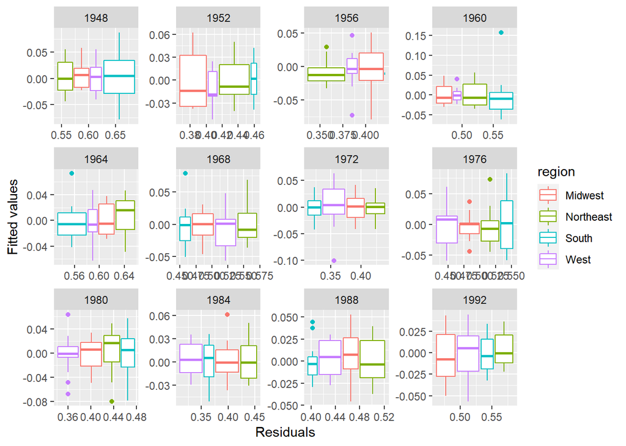

# 6 Discussion

In part 3, we developed linear models to predict the outcomes of presidential elections in the US. Although the results appeared appealing, they were incorrect because they did not account for the hierarchical structure of the data. In part 4, we built a multilevel model that addressed this issue by accounting for the clustered effects. The results were more satisfactory, as the model took into account the hierarchical structure of the data. Our analysis showed that the share of votes in previous elections is a strong predictor of upcoming elections, and candidates who were born in the same region as the voters have an advantage in the region. Regional effects, such as the South being more inclined towards the Republican party, were also observed.

To enhance our study, it would be valuable to re-evaluate the models using more recent election data. Our analysis only considered elections from 1948 to 1992, and since then, there have been significant shifts in American politics, including the 2008 election of Barack Obama and the 2016 election of Donald Trump. Including other relevant explanatory variables, such as metrics for social media communication, if available, could also provide a more comprehensive understanding of the dynamics that shape the outcomes of presidential elections.

# 7 References

[1] “The American Political Tradition and the Men Who Made It” by Richard Hofstadter (1948)

[2] “America Divided: The Civil War of the 1960s” by Maurice Isserman and Michael Kazin (2009)